# Week 09: R for Data Analytics - Regression Analysis

Ziyuan Huang

2026-01-29

**Machine:** MEL_DEL - Windows 10 x64

**Random Seed Set To:** 3284

## Introduction

Regression analysis is one of the most powerful and widely-used statistical techniques in data science. While correlation analysis (covered in Week 08) tells us whether two variables are related, regression analysis goes further: it allows us to **predict** one variable from one or more other variables, and to **understand the strength** of those relationships.

In this practical tutorial, we’ll learn how to conduct regression analysis using R, working with real data about mental health outcomes. By the end of this session, you should be able to:

### Learning Objectives

1. Understand the conceptual foundations of simple linear regression
2. Fit a simple linear regression model and interpret model output
3. Extend to multiple regression with several predictors
4. Test regression assumptions (linearity, normality, homoscedasticity, independence)
5. Identify outliers and influential cases using diagnostic statistics
6. Compare regression models using hierarchical regression
7. Work with categorical predictors using dummy coding
8. Calculate and interpret effect sizes in regression (R², semi-partial correlations)
9. Produce APA-formatted regression tables
10. Understand when regression assumptions are violated and potential solutions

### Required Packages

We’ll use several R packages for this analysis. Install them if needed:

```r
install.packages("tidyverse")      # Data manipulation and ggplot2
install.packages("rio")            # Easy data import (CSV, SPSS, Excel)
install.packages("car")            # Diagnostics (VIF, leverage, Cook's D)
install.packages("corrplot")       # Correlation visualization
install.packages("psych")          # Descriptive statistics
install.packages("ppcor")          # Partial & semi-partial correlations
```

**Load libraries:**

```r
library(tidyverse)      # ggplot2, dplyr
library(rio)            # import() function
library(car)            # vif(), influencePlot()
library(corrplot)       # Visual correlation matrices
library(psych)          # Descriptive statistics
library(ppcor)          # spcor(), ppcor() for partial correlations
library(knitr)          # Markdown tables
library(kableExtra)     # Table formatting
```

## Part 1: Understanding Regression (Conceptual Foundations)

### What is Regression?

Regression is a statistical technique for modeling the relationship between variables. In **simple linear regression**, we have: - One **independent variable** (predictor, X) - One **dependent variable** (outcome, Y)

We fit a straight line through the data to predict Y from X. The line is described by the equation:

$$\hat{Y}_i = b_0 + b_1X_i +
\varepsilon_i$$

Where: - $\hat{Y}_i$ = predicted value for person i - $b_0$ = intercept (where the line crosses the y-axis when X=0) - $b_1$ = slope (how much Y changes for each unit increase in X) - $\varepsilon_i$ = error (residual) for person i

### Why Do We Use Regression?

1. **Prediction:** Estimate outcomes for new individuals
2. **Understanding relationships:** Quantify how X affects Y
3. **Hypothesis testing:** Test whether relationships are statistically significant
4. **Controlling for confounds:** In multiple regression, examine one predictor while holding others constant

### The Logic of Least Squares

Regression finds the “best fit” line by minimizing the **sum of squared residuals** (SSR):

$$SSR = \sum_{i=1}^{n} (Y_i -
\hat{Y}_i)^2$$

This means we want predictions that are as close as possible to the actual data.

> **Plain English:** Think of a **residual** as the “miss” or “error” of our prediction. If we predict a depression score of 20 but the person actually scored 25, the residual is 5. These residuals represent the error present in the model. If a model fits the data well, all residuals will be small. Regression tries to find the line that makes these “misses” as small as possible for everyone.

## Part 2: Data Import & Exploration

### Loading Our Regression Data

We’ll work with mental health data examining predictors of depression scores. The dataset contains: - **CESD_total:** Center for Epidemiologic Studies Depression Scale (our outcome) - **PIL_total:** Purpose in Life subscale (meaning) - **AUDIT_TOTAL_NEW:** Alcohol Use Disorder Identification Test - **DAST_TOTAL_NEW:** Drug Abuse Screening Test

```r
# Import the regression data
regression_data <- import("data/regression_data.sav")

# Quick look at the data
head(regression_data)
```

|  | age | gender | ethnicit | major | minor | gpa | class | PIL_total | CESD_total | AUDIT_TOTAL_NEW | DAST_TOTAL_NEW |
| --- | --- | --- | --- | --- | --- | --- | --- | --- | --- | --- | --- |
| 1 | 18 | -1 | 2 | political sci |  | 3.0 | 1 | 121 | 28 | 1 | 0 |
| 2 | 18 | -1 | 1 | pre-pharm |  | NA | 1 | 76 | 37 | 5 | 0 |
| 3 | 18 | -1 | 1 | pre-med | undecided | 3.5 | 1 | 98 | 20 | 3 | 0 |
| 4 | 20 | -1 | 3 | psychology | Spanish | 3.0 | 3 | 122 | 15 | 3 | 1 |
| 5 | 32 | -1 | 1 | psychology | accounting | 3.5 | 4 | 99 | 7 | 2 | 0 |
| 6 | 19 | -1 | 1 | exercise scie |  | 3.8 | 2 | 134 | 7 | 3 | 0 |

```r
dim(regression_data)
```

```
## [1] 267  11
```

```r
str(regression_data)
```

```
## 'data.frame':    267 obs. of  11 variables:
##  $ age            : num  18 18 18 20 32 19 19 18 19 19 ...
##   ..- attr(*, "format.spss")= chr "F8.2"
##  $ gender         : num  -1 -1 -1 -1 -1 -1 -1 -1 -1 -1 ...
##   ..- attr(*, "format.spss")= chr "F8.0"
##   ..- attr(*, "labels")= Named num [1:2] -1 1
##   .. ..- attr(*, "names")= chr [1:2] "male" "female"
##  $ ethnicit       : num  2 1 1 3 1 1 2 2 1 3 ...
##   ..- attr(*, "format.spss")= chr "F8.0"
##   ..- attr(*, "labels")= Named num [1:6] 1 2 3 4 5 6
##   .. ..- attr(*, "names")= chr [1:6] "caucasian" "african amer" "hispanic" "asian/pacific islander" ...
##  $ major          : chr  "political sci" "pre-pharm" "pre-med" "psychology" ...
##   ..- attr(*, "format.spss")= chr "A39"
##  $ minor          : chr  "" "" "undecided" "Spanish" ...
##   ..- attr(*, "format.spss")= chr "A39"
##  $ gpa            : num  3 NA 3.5 3 3.5 3.8 3.2 4 NA 3.3 ...
##   ..- attr(*, "format.spss")= chr "F8.2"
##  $ class          : num  1 1 1 3 4 2 2 1 2 1 ...
##   ..- attr(*, "format.spss")= chr "F8.0"
##   ..- attr(*, "labels")= Named num [1:4] 1 2 3 4
##   .. ..- attr(*, "names")= chr [1:4] "freshman" "sophomore" "junior" "senior"
##  $ PIL_total      : num  121 76 98 122 99 134 102 124 126 112 ...
##   ..- attr(*, "format.spss")= chr "F8.2"
##   ..- attr(*, "display_width")= int 11
##  $ CESD_total     : num  28 37 20 15 7 7 27 10 9 8 ...
##   ..- attr(*, "format.spss")= chr "F8.2"
##   ..- attr(*, "display_width")= int 12
##  $ AUDIT_TOTAL_NEW: num  1 5 3 3 2 3 2 1 1 7 ...
##   ..- attr(*, "format.spss")= chr "F8.2"
##   ..- attr(*, "display_width")= int 17
##  $ DAST_TOTAL_NEW : num  0 0 0 1 0 0 1 0 0 1 ...
##   ..- attr(*, "format.spss")= chr "F8.2"
##   ..- attr(*, "display_width")= int 16
```

### Descriptive Statistics

```r
# Summary statistics
summary(regression_data)
```

```
##       age            gender           ethnicit        major
##  Min.   :18.00   Min.   :-1.0000   Min.   :1.000   Length:267
##  1st Qu.:18.00   1st Qu.: 1.0000   1st Qu.:1.000   Class :character
##  Median :19.00   Median : 1.0000   Median :1.000   Mode  :character
##  Mean   :19.14   Mean   : 0.5131   Mean   :1.406
##  3rd Qu.:19.00   3rd Qu.: 1.0000   3rd Qu.:1.000
##  Max.   :41.00   Max.   : 1.0000   Max.   :6.000
##  NA's   :1                         NA's   :1
##     minor                gpa            class         PIL_total
##  Length:267         Min.   :1.000   Min.   :1.000   Min.   : 60.0
##  Class :character   1st Qu.:2.900   1st Qu.:1.000   1st Qu.:103.0
##  Mode  :character   Median :3.200   Median :1.000   Median :111.0
##                     Mean   :3.211   Mean   :1.584   Mean   :110.7
##                     3rd Qu.:3.600   3rd Qu.:2.000   3rd Qu.:121.0
##                     Max.   :4.600   Max.   :4.000   Max.   :138.0
##                     NA's   :46
##    CESD_total   AUDIT_TOTAL_NEW  DAST_TOTAL_NEW
##  Min.   : 0.0   Min.   : 0.000   Min.   :0.000
##  1st Qu.: 7.0   1st Qu.: 2.000   1st Qu.:0.000
##  Median :11.0   Median : 5.000   Median :0.000
##  Mean   :13.2   Mean   : 6.807   Mean   :0.906
##  3rd Qu.:17.0   3rd Qu.:11.000   3rd Qu.:1.000
##  Max.   :47.0   Max.   :31.000   Max.   :9.000
##                                  NA's   :1
```

```r
# More detailed descriptives using psych package
psych::describe(regression_data)
```

|  | vars | n | mean | sd | median | trimmed | mad | min | max | range | skew | kurtosis | se |
| --- | --- | --- | --- | --- | --- | --- | --- | --- | --- | --- | --- | --- | --- |
| age | 1 | 266 | 19.1353383 | 2.0513482 | 19.0 | 18.7850467 | 1.48260 | 18 | 41.0 | 23.0 | 6.1366185 | 53.9898249 | 0.12577623 |
| gender | 2 | 267 | 0.5131086 | 0.8599356 | 1.0 | 0.6372093 | 0.00000 | -1 | 1.0 | 2.0 | -1.1888957 | -0.5886897 | 0.05262720 |
| ethnicit | 3 | 266 | 1.4060150 | 0.9637787 | 1.0 | 1.1775701 | 0.00000 | 1 | 6.0 | 5.0 | 3.3022933 | 11.7892103 | 0.05909306 |
| major* | 4 | 267 | 41.9850187 | 23.3413651 | 44.0 | 42.0930233 | 32.61720 | 1 | 78.0 | 77.0 | -0.1060050 | -1.3417712 | 1.42846834 |
| minor* | 5 | 267 | 10.9588015 | 15.4570162 | 1.0 | 8.1488372 | 0.00000 | 1 | 46.0 | 45.0 | 1.2334078 | -0.1222645 | 0.94595403 |
| gpa | 6 | 221 | 3.2114027 | 0.5209112 | 3.2 | 3.2383616 | 0.59304 | 1 | 4.6 | 3.6 | -0.5388623 | 0.6189967 | 0.03504028 |
| class | 7 | 267 | 1.5842697 | 0.9315964 | 1.0 | 1.3860465 | 0.00000 | 1 | 4.0 | 3.0 | 1.4921085 | 1.0638683 | 0.05701278 |
| PIL_total | 8 | 267 | 110.6652552 | 13.9895124 | 111.0 | 111.6354564 | 13.34340 | 60 | 138.0 | 78.0 | -0.7017384 | 0.5757364 | 0.85614426 |
| CESD_total | 9 | 267 | 13.2041199 | 9.4079684 | 11.0 | 11.9372093 | 7.41300 | 0 | 47.0 | 47.0 | 1.2629254 | 1.2739235 | 0.57575832 |
| AUDIT_TOTAL_NEW | 10 | 267 | 6.8067162 | 5.8157493 | 5.0 | 6.2064801 | 5.93040 | 0 | 31.0 | 31.0 | 0.8995950 | 0.5413627 | 0.35591807 |

[output cut: 1 more lines]

### Visualizing Distributions

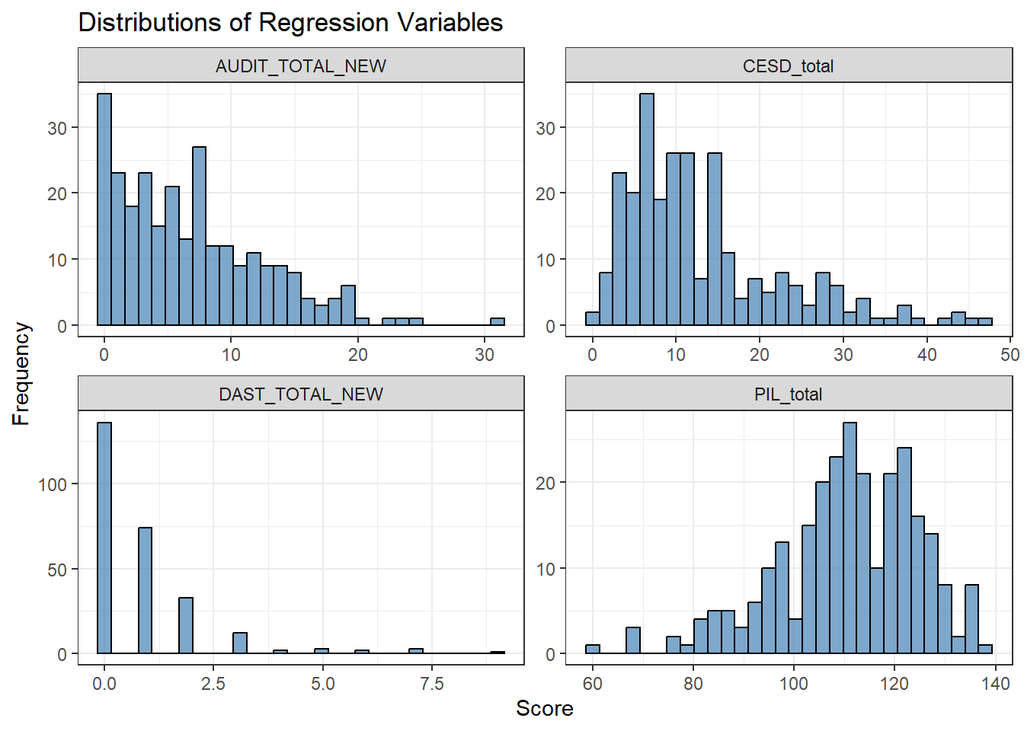

```r
# Create histograms for each numeric variable
regression_data[, c("CESD_total", "PIL_total", "AUDIT_TOTAL_NEW", "DAST_TOTAL_NEW")] %>%
  as.data.frame() %>%
  pivot_longer(everything()) %>%
  ggplot(aes(x = value)) +
  geom_histogram(bins = 30, fill = "steelblue", color = "black", alpha = 0.7) +
  facet_wrap(~name, scales = "free") +
  theme_bw() +
  labs(title = "Distributions of Regression Variables",
       x = "Score", y = "Frequency")
```

### Check for Missing Data

```r
# Count missing values
colSums(is.na(regression_data))
```

```
##             age          gender        ethnicit           major           minor
##               1               0               1               0               0
##             gpa           class       PIL_total      CESD_total AUDIT_TOTAL_NEW
##              46               0               0               0               0
##  DAST_TOTAL_NEW
##               1
```

```r
# Percentage missing
colMeans(is.na(regression_data)) * 100
```

```
##             age          gender        ethnicit           major           minor
##       0.3745318       0.0000000       0.3745318       0.0000000       0.0000000
##             gpa           class       PIL_total      CESD_total AUDIT_TOTAL_NEW
##      17.2284644       0.0000000       0.0000000       0.0000000       0.0000000
##  DAST_TOTAL_NEW
##       0.3745318
```

## Part 3: Simple Linear Regression

### Correlation as a Starting Point

Before fitting regression, let’s examine correlations between depression (CESD) and our predictors:

```r
# Pearson correlations with p-values using Hmisc
# Create correlation matrix
numeric_vars <- c("CESD_total", "PIL_total", "AUDIT_TOTAL_NEW", "DAST_TOTAL_NEW")
corr_matrix <- cor(regression_data[, numeric_vars], use = "complete.obs")
print(corr_matrix)
```

```
##                  CESD_total  PIL_total AUDIT_TOTAL_NEW DAST_TOTAL_NEW
## CESD_total       1.00000000 -0.5846550      0.09594426      0.2169417
## PIL_total       -0.58465498  1.0000000     -0.13103854     -0.1680770
## AUDIT_TOTAL_NEW  0.09594426 -0.1310385      1.00000000      0.5194087
## DAST_TOTAL_NEW   0.21694168 -0.1680770      0.51940873      1.0000000
```

```r
# For p-values, use a simple approach with cor.test
cat("\nPearson Correlations with Depression (CESD_total):\n")
```

```
##
## Pearson Correlations with Depression (CESD_total):
```

```r
for (var in numeric_vars[-1]) {  # -1 excludes CESD
  test <- cor.test(regression_data$CESD_total, regression_data[[var]])
  cat(var, ": r =", round(test$estimate, 3), ", p =", round(test$p.value, 4), "\n")
}
```

```
## PIL_total : r = -0.58 , p = 0
## AUDIT_TOTAL_NEW : r = 0.093 , p = 0.1295
## DAST_TOTAL_NEW : r = 0.217 , p = 4e-04
```

### Fitting a Simple Regression Model

Let’s predict depression (CESD_total) from purpose in life (PIL_total):

```r
# Create a clean dataset with no missing values for regression comparison
regression_data_clean <- regression_data %>%
  dplyr::select(CESD_total, PIL_total, AUDIT_TOTAL_NEW, DAST_TOTAL_NEW) %>%
  drop_na()

# Fit the simple regression model on clean data
model_simple <- lm(CESD_total ~ PIL_total, data = regression_data_clean)

# View results
summary(model_simple)
```

```
##
## Call:
## lm(formula = CESD_total ~ PIL_total, data = regression_data_clean)
##
## Residuals:
##     Min      1Q  Median      3Q     Max
## -15.928  -5.385  -1.522   3.213  29.521
##
## Coefficients:
##             Estimate Std. Error t value Pr(>|t|)
## (Intercept) 56.81537    3.75199   15.14   <2e-16 ***
## PIL_total   -0.39368    0.03362  -11.71   <2e-16 ***
## ---
## Signif. codes:  0 '***' 0.001 '**' 0.01 '*' 0.05 '.' 0.1 ' ' 1
##
## Residual standard error: 7.655 on 264 degrees of freedom
## Multiple R-squared:  0.3418, Adjusted R-squared:  0.3393
## F-statistic: 137.1 on 1 and 264 DF,  p-value: < 2.2e-16
```

### Interpreting the Output

The key elements of the summary are:

- **Intercept (b₀):** When PIL_total = 0, predicted depression = intercept value
- **PIL_total coefficient (b₁):** For each 1-unit increase in purpose in life, depression decreases by this amount
- **Standard Error:** Uncertainty in the coefficient estimate
- **t-value & Pr(>|t|):** Tests whether coefficient differs from zero
- **R-squared (R²):** Proportion of variance in depression explained by purpose in life
- **F-statistic:** Tests overall model significance

> **Plain English (F-statistic):** The **F-ratio** is a measure of the ratio of the variation explained by the model and the variation explained by unsystematic factors. In other words, it is the ratio of how good the model is against how bad it is (how much error there is). If the F-ratio is less than 1, it means there is more error than explained variance.

> **Plain English (t-statistic):** The **t-statistic** tests whether a specific predictor contributes significantly to the model. Like F, it is based on the ratio of explained variance against unexplained variance, but for a single variable. It tests whether the coefficient (b-value) is significantly different from 0.

> **Plain English (R-squared):** $R^2$ is a measure of how much of the variability in the outcome is accounted for by the predictors. Think of it as the “percentage of the story” that our model explains. If $R^2 = 0.33$, it means our model explains 33% of the differences in depression scores between people. The remaining 67% is unexplained variance (due to factors we didn’t measure).

> **Plain English (Adjusted R-squared):** $R^2$ tends to get bigger just by adding more variables, even if they are useless. **Adjusted $R^2$** corrects for this. It estimates how well your model would work in the “real world” (the population) rather than just your specific sample. It’s usually a bit lower than regular $R^2$.

> **Plain English (Standard Error):** The **Standard Error (SE)** tells us how much the coefficient (b-value) might vary if we took a different sample of people. A small SE means we are very confident in our estimate of the relationship. A large SE means our estimate is wobbly and uncertain.

> **Plain English (p-value):** In regression, the **p-value** tells us the probability of seeing a relationship this strong if there really was *no relationship* in the real world. If $p < .05$, we conclude the relationship is “statistically significant” (real enough to publish).

```r
# Extract key values for interpretation
cat("Simple Regression: CESD ~ PIL\n")
```

```
## Simple Regression: CESD ~ PIL
```

```r
cat("Intercept:", coef(model_simple)[1], "\n")
```

```
## Intercept: 56.81537
```

```r
cat("PIL_total slope:", coef(model_simple)[2], "\n")
```

```
## PIL_total slope: -0.3936757
```

```r
cat("R-squared:", summary(model_simple)$r.squared, "\n")
```

```
## R-squared: 0.3418214
```

```r
cat("Adjusted R-squared:", summary(model_simple)$adj.r.squared, "\n")
```

```
## Adjusted R-squared: 0.3393283
```

### Visualizing the Regression Line

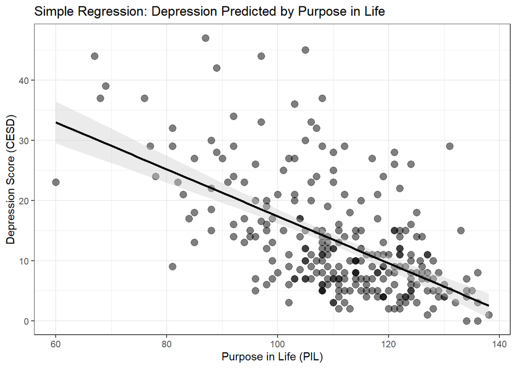

```r
# Create cleanup theme
cleanup <- theme(panel.grid.major = element_blank(),
                panel.grid.minor = element_blank(),
                panel.background = element_blank(),
                axis.line.x = element_line(color = 'black'),
                axis.line.y = element_line(color = 'black'),
                legend.key = element_rect(fill = 'white'),
                text = element_text(size = 12))

# Plot with regression line
ggplot(regression_data, aes(x = PIL_total, y = CESD_total)) +
  geom_point(alpha = 0.5, size = 3) +
  geom_smooth(method = "lm", se = TRUE, color = "black", fill = "grey80") +
  xlab("Purpose in Life (PIL)") +
  ylab("Depression Score (CESD)") +
  ggtitle("Simple Regression: Depression Predicted by Purpose in Life") +
  cleanup +
  theme_bw()
```

## Part 4: Multiple Regression

### Adding More Predictors

Depression likely has multiple causes. Let’s add alcohol and drug use as predictors:

```r
# Fit multiple regression model on the same clean data
model_multiple <- lm(CESD_total ~ PIL_total + AUDIT_TOTAL_NEW + DAST_TOTAL_NEW,
                     data = regression_data_clean)

# View results
summary(model_multiple)
```

```
##
## Call:
## lm(formula = CESD_total ~ PIL_total + AUDIT_TOTAL_NEW + DAST_TOTAL_NEW,
##     data = regression_data_clean)
##
## Residuals:
##     Min      1Q  Median      3Q     Max
## -19.619  -5.172  -1.256   3.420  28.847
##
## Coefficients:
##                 Estimate Std. Error t value Pr(>|t|)
## (Intercept)     55.16374    3.88905  14.184   <2e-16 ***
## PIL_total       -0.38158    0.03384 -11.276   <2e-16 ***
## AUDIT_TOTAL_NEW -0.09211    0.09391  -0.981    0.328
## DAST_TOTAL_NEW   1.03415    0.39871   2.594    0.010 *
## ---
## Signif. codes:  0 '***' 0.001 '**' 0.01 '*' 0.05 '.' 0.1 ' ' 1
##
## Residual standard error: 7.585 on 262 degrees of freedom
## Multiple R-squared:  0.3587, Adjusted R-squared:  0.3513
## F-statistic: 48.84 on 3 and 262 DF,  p-value: < 2.2e-16
```

### Comparing Models

We can compare the simple and multiple models:

```r
# ANOVA comparison
anova(model_simple, model_multiple)
```

|  | Res.Df | RSS | Df | Sum of Sq | F | Pr(>F) |
| --- | --- | --- | --- | --- | --- | --- |
| 1 | 264 | 15470.48 | NA | NA | NA | NA |
| 2 | 262 | 15074.47 | 2 | 396.0093 | 3.441395 | 0.03347459 |

```r
# Or use R² to compare
cat("Simple Model R²:", summary(model_simple)$r.squared, "\n")
```

```
## Simple Model R²: 0.3418214
```

```r
cat("Multiple Model R²:", summary(model_multiple)$r.squared, "\n")
```

```
## Multiple Model R²: 0.3586693
```

```r
cat("Improvement:",
    summary(model_multiple)$r.squared - summary(model_simple)$r.squared, "\n")
```

```
## Improvement: 0.01684788
```

### Standardized Coefficients

The regression coefficients above are **unstandardized** (also called raw coefficients). They depend on the scale of measurement. Often we want **standardized coefficients** (beta weights) which are on a common scale:

```r
# Standardize the variables manually
regression_data_std <- regression_data_clean %>%
  dplyr::select(CESD_total, PIL_total, AUDIT_TOTAL_NEW, DAST_TOTAL_NEW) %>%
  mutate(across(everything(), scale))

# Fit model with standardized variables
model_multiple_std <- lm(CESD_total ~ PIL_total + AUDIT_TOTAL_NEW + DAST_TOTAL_NEW,
                         data = regression_data_std)

# Extract standardized coefficients
coef(model_multiple_std)
```

```
##     (Intercept)       PIL_total AUDIT_TOTAL_NEW  DAST_TOTAL_NEW
##    7.461120e-17   -5.666880e-01   -5.686394e-02    1.512301e-01
```

## Part 5: Regression Assumptions

> **Plain English (Assumptions):** * **Linearity:** The relationship between predictors and the outcome is a straight line. * **Homoscedasticity:** At each level of the predictor, the spread (variance) of the “misses” (residuals) should be roughly the same. If the points fan out like a funnel, that’s bad (heteroscedasticity). * **Independence:** The errors for one person shouldn’t be related to the errors for another person. * **Normality:** The errors should be normally distributed (bell curve).

### Assumption 1: Linearity

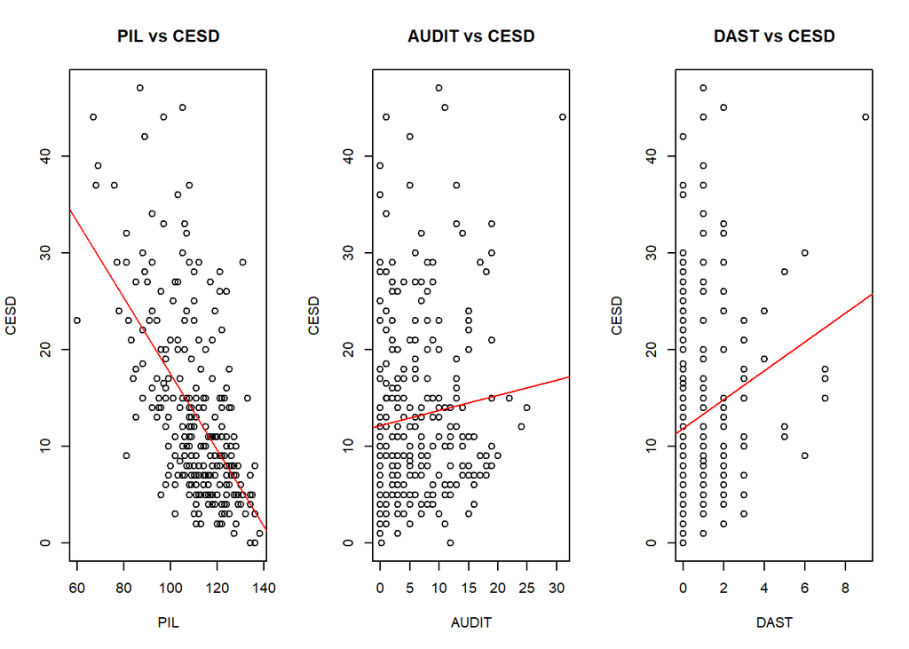

```r
par(mfrow = c(1, 3))
plot(regression_data_clean$PIL_total, regression_data_clean$CESD_total,
     main = "PIL vs CESD", xlab = "PIL", ylab = "CESD")
abline(lm(CESD_total ~ PIL_total, regression_data_clean), col = "red")

plot(regression_data_clean$AUDIT_TOTAL_NEW, regression_data_clean$CESD_total,
     main = "AUDIT vs CESD", xlab = "AUDIT", ylab = "CESD")
abline(lm(CESD_total ~ AUDIT_TOTAL_NEW, regression_data_clean), col = "red")

plot(regression_data_clean$DAST_TOTAL_NEW, regression_data_clean$CESD_total,
     main = "DAST vs CESD", xlab = "DAST", ylab = "CESD")
abline(lm(CESD_total ~ DAST_TOTAL_NEW, regression_data_clean), col = "red")
```

```r
par(mfrow = c(1, 1))
```

### Assumption 2: Normality of Residuals

Residuals (errors) should be normally distributed:

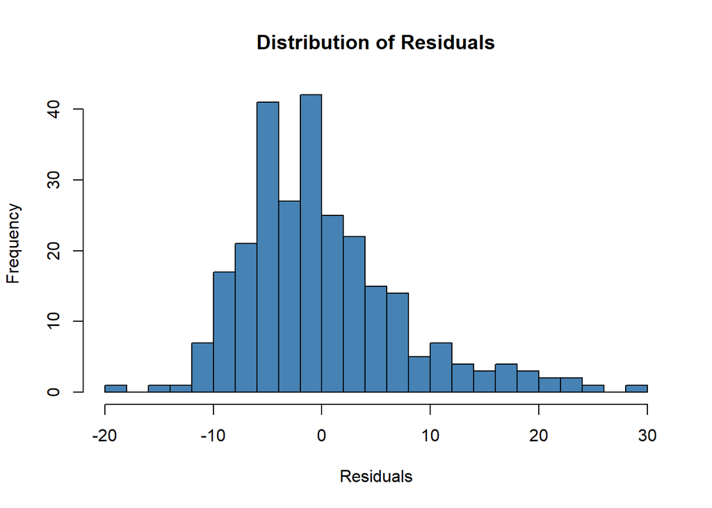

```r
# Extract residuals
residuals_model <- residuals(model_multiple)

# Histogram of residuals
hist(residuals_model, breaks = 20, main = "Distribution of Residuals",
     xlab = "Residuals", ylab = "Frequency", col = "steelblue")
```

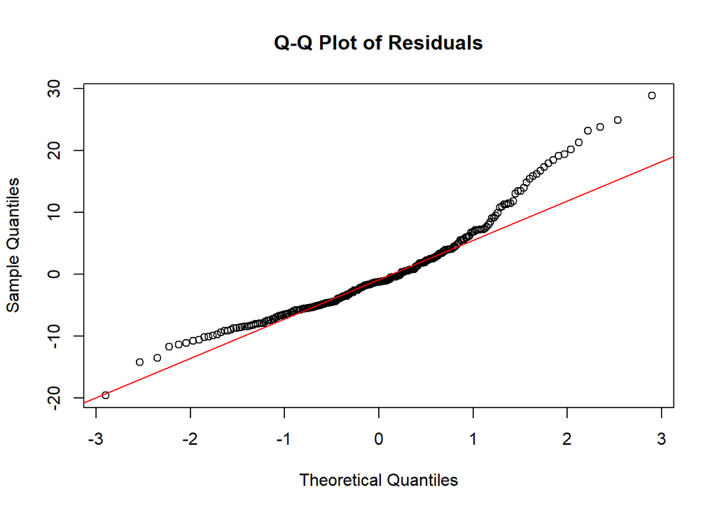

```r
# Q-Q plot (quantile-quantile plot)
qqnorm(residuals_model, main = "Q-Q Plot of Residuals")
qqline(residuals_model, col = "red")
```

```r
# Shapiro-Wilk test for normality
shapiro.test(residuals_model)
```

```
##
##  Shapiro-Wilk normality test
##
## data:  residuals_model
## W = 0.93583, p-value = 2.383e-09
```